# DV_RProject3 : Electricity Rates For Investor Owned and Non-Investor Owned Utilities

Syairah Ridzuan, Madeline Packard, Arthur DeVitalis

March 4, 2015

Investor Owned Utilities (IOU) is defined as utilities that are owned by private companies instead of state or federal public agency (EnergyVortex.com). Both datasets used in this projects are made public by the National Renewable Energy Laboratory (NREL) and Ventyx in February 2011. The datasets contain the average electricity rates for residential, commercial and industrial purposes for each utility.

## Loading the Datasets from Oracle Database Into R Studio

The datasets pulled from the Oracle database include the average electricity rates for residential, commercial and industrial purposes for each utility, details about the companies that provide the utilities as well as the zipcodes where the utilities are located.

```r
source("../01 Data/io_df.R", echo = TRUE)
```

```
##
## > io_df <- data.frame(fromJSON(getURL(URLencode("129.152.144.84:5001/rest/native/?query=\"select * from electricity_io \""),
## +     httpheader = c(DB  .... [TRUNCATED]
```

We realized that the datasets lack one valuable information which is a column that contains the states where the utilities are located. Nonetheless, with the information that we have on zipcodes, we are able to create the ‘state’ column and identify the states based on the corresponding zipcodes. Thus, we added ‘state’ column on both datasets.

```r
source("../01 Data/adding_io_state.R", echo = TRUE)
```

```
##
## > io_df["state"] <- io_df$ZIPCODE
##
## > for (x in 1:length(io_df$state)) {
## +     if (io_df$state[x] >= 99500 && io_df$state[x] <= 99999) {
## +         io_df$state[x] <- "Alaska"
## +         ne .... [TRUNCATED]
##
## > io_df$state <- as.factor(io_df$state)
##
## > levels(io_df$state)
##  [1] "Alabama"        "Alaska"         "Arizona"        "Arkansas"
##  [5] "California"     "Delaware"       "Florida"        "Georgia"
##  [9] "Hawaii"         "Indiana"        "Iowa"           "Kentucky"
## [13] "Maine"          "Massachussetts" "Minnesota"      "New Jersey"
## [17] "North Carolina" "Oregon"         "Rhode Island"   "South Dakota"
## [21] "Vermont"        "Washington"     "Washington DC"
##
## > io_df %>% tbl_df
## Source: local data frame [30,351 x 7]
##
##    ZIPCODE COMPANY_ID                       COMPANY_NAME COMMERCIAL_RATE
## 1    71701        814               Entergy Arkansas Inc           71.81
## 2    36553        195                   Alabama Power Co           81.85
## 3    83801      20169                        Avista Corp           72.22
## 4     2176       1998                   Boston Edison Co          193.53
## 5    30308       7140                   Georgia Power Co           76.30
## 6    13415      13511 New York State Electric & Gas Corp          122.51
## 7    52132       9162        Interstate Power & Light Co            0.00
## 8    94520      14328        Pacific Gas and Electric Co          138.50
## 9    16674      14711           Pennsylvania Electric Co           78.89
## 10   25248        733               Appalachian Power Co           52.60
## ..     ...        ...                                ...             ...
## Variables not shown: INDUSTRIAL_RATE (dbl), RESIDENTIAL_RATE (dbl), state
##   (fctr)
```

```r
source("../01 Data/non_io_df.R", echo = TRUE)
```

```
##
## > nonio_df <- data.frame(fromJSON(getURL(URLencode("129.152.144.84:5001/rest/native/?query=\"select * from electricity_nonio \""),
## +     httpheader = .... [TRUNCATED]
##
## > nonio_df %>% tbl_df
## Source: local data frame [34,666 x 6]
##
##    ZIPCODE COMPANY_ID                           COMPANY_NAME
## 1    32541       3502       Choctawhatchee Electric Coop Inc
## 2    61876       5585           Eastern Illini Electric Coop
## 3     5836       8104           Hardwick Electric Light Dept
## 4    44214      11200  Lorain-Medina Rural Electric Coop Inc
## 5    35761       6234    Fayetteville Electric & Gas Systems
## 6    58772      B1959                Saskatchewan Power Corp
## 7    68825       4911    Dawson County Public Power District
## 8    13035      14125       Oneida-Madison Electric Coop Inc
## 9    50149       3722               Clarke Electric Coop Inc
## 10   80862      13058 Mountain View Electric Association Inc
## ..     ...        ...                                    ...
## Variables not shown: COMMERCIAL_RATE (dbl), INDUSTRIAL_RATE (dbl),
##   RESIDENTIAL_RATE (dbl)
```

The following `myplot` function entails the plotting of categorical variable in the form of point plots while `myplot1` function plots the quantitative variables in the form of histograms.

```r
source("../01 Data/plot_function_qualitative.R", echo = TRUE)
```

```
##
## > myplot <- function(df, x) {
## +     names(df) <- c("x", "count")
## +     ggplot(df, aes(x = x, y = count)) + geom_point() + xlab(x) +
## +         theme(a .... [TRUNCATED]
```

Notice `theme(axis.text.x=element_blank())` inside the code above; this removes the labels on the x-axes for all qualitative variables. This is because there are a lot of distinct datapoints in both datasets and they eventually made the axes become unreadable. In addition, company name and company id give us less insights compared to the number of utilities they manage which could possibly be located across many states.

```r
source("../01 Data/categoricals_io.R", echo = TRUE)
```

```
##
## > categoricals_io <- eval(parse(text = substring(getURL(URLencode("http://129.152.144.84:5001/rest/native/?query=\"select * from electricity_io\""),
##  .... [TRUNCATED]
```

```r
source("../03 Visualizations/io_qualitative.R", echo = TRUE)
```

```
##
## > l <- list()
##
## > for (i in names(io_df)) {
## +     if (i %in% categoricals_io[[1]]) {
## +         a <- data.frame(fromJSON(getURL(URLencode("129.152.144.84:5001/rest/nat ..." ... [TRUNCATED]
```

```r
source("../03 Visualizations/storing_io_qualitative.R", echo = FALSE)
```

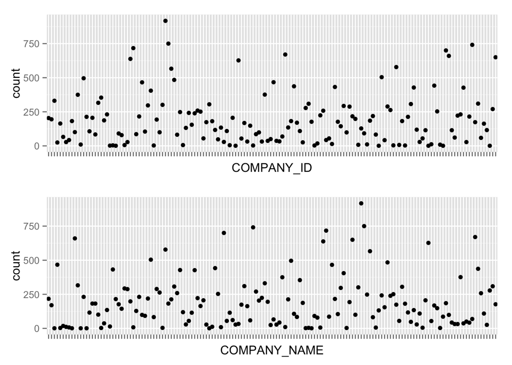

```r
source("../01 Data/plot_function_quantitative.R", echo = TRUE)
```

```
##
## > myplot1 <- function(df, x) {
## +     names(df) <- c("x")
## +     ggplot(df, aes(x = x)) + geom_histogram() + xlab(x) + theme(axis.text.x = element_text( .... [TRUNCATED]
```

```r
source("../03 Visualizations/io_quantitative.R", echo = TRUE)
```

```
##
## > m <- list()
##
## > for (i in names(io_df)) {
## +     if (i %in% categoricals_io[[2]]) {
## +         a <- data.frame(fromJSON(getURL(URLencode("129.152.144.84:5001/rest/nat ..." ... [TRUNCATED]
```

```r
source("../03 Visualizations/storing_io_quantitative.R", echo = FALSE)
```

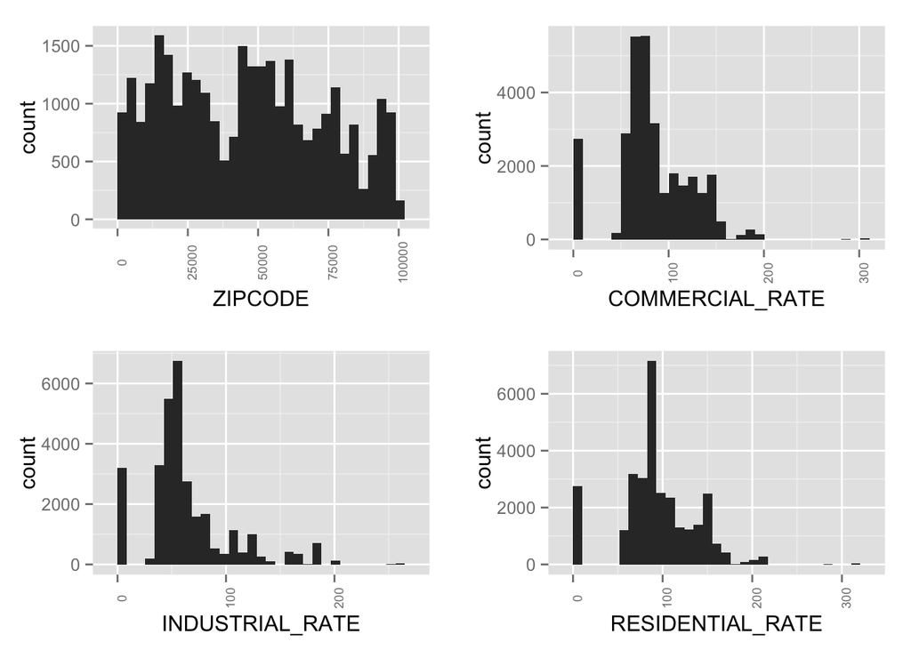

The same steps above are applied to non-investor owned utilities dataset. The following shows the visualizations produced using `myplot` and `myplot1` functions on ‘nonio_df’ dataset.

```r
source("../03 Visualizations/storing_non_io_qualitative.R", echo = TRUE)
```

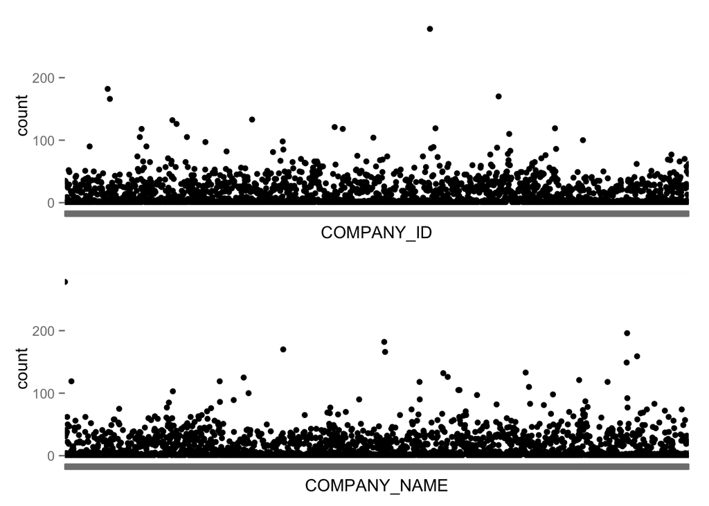

```
##
## > pushViewport(viewport(layout = grid.layout(2, 12)))
##
## > print(n[[1]], vp = viewport(layout.pos.row = 1, layout.pos.col = 1:12))
##
## > print(n[[2]], vp = viewport(layout.pos.row = 2, layout.pos.col = 1:12))
```

```r
source("../03 Visualizations/storing_non_io_quantitative.R", echo = TRUE)
```

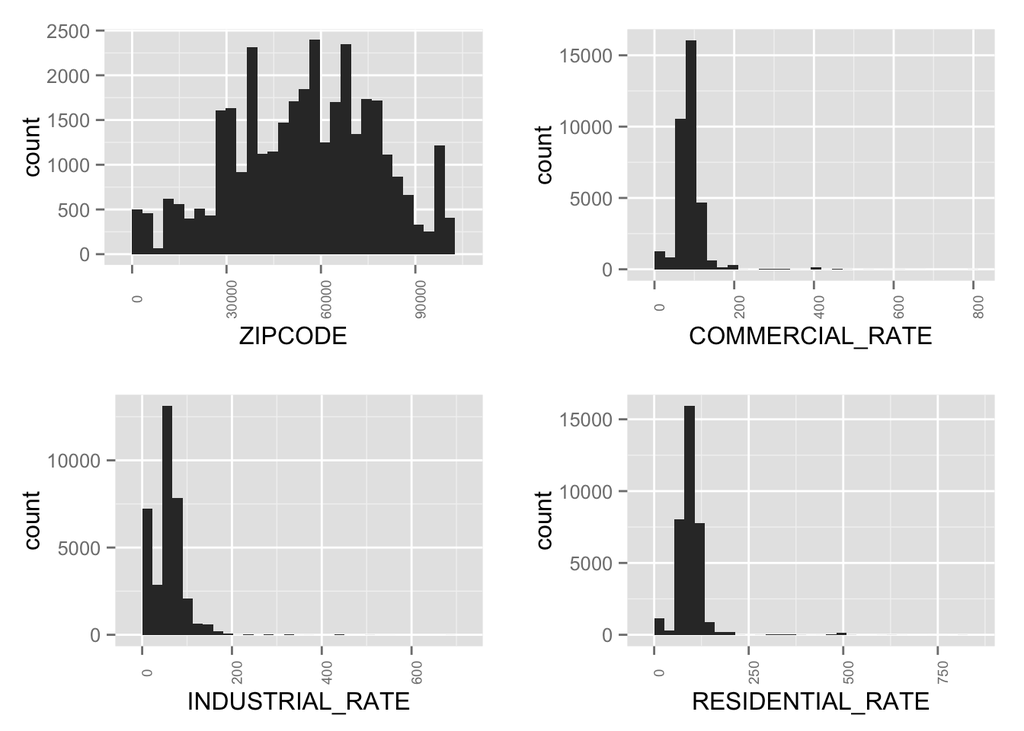

```
##
## > pushViewport(viewport(layout = grid.layout(2, 12)))
##
## > print(o[[1]], vp = viewport(layout.pos.row = 1, layout.pos.col = 1:6))
##
## > print(o[[2]], vp = viewport(layout.pos.row = 1, layout.pos.col = 7:12))
##
## > print(o[[3]], vp = viewport(layout.pos.row = 2, layout.pos.col = 1:6))
##
## > print(o[[4]], vp = viewport(layout.pos.row = 2, layout.pos.col = 7:12))
```

## Joining Datasets

Using the `dplyr` package, we can combine both datasets and yield quite valuable information.

For instance, the following code combines both datasets using inner join, which matches records based on their zipcode areas. It is important to note that we avoid using `"COMPANY NAME"` and `"COMPANY ID"` for comparing the two datasets. This is because a utility company can either be a private enterprise or a government-run agency but it could not be both of the entities.

```r
source("../01 Data/inner_join.R", echo = TRUE)
```

```
##
## > ij_df <- inner_join(io_df, nonio_df, by = c("ZIPCODE"))
##
## > ij_df %>% tbl_df
## Source: local data frame [27,573 x 13]
##
##    ZIPCODE COMPANY_ID.x                     COMPANY_NAME.x
## 1    71701          814               Entergy Arkansas Inc
## 2    36553          195                   Alabama Power Co
## 3    83801        20169                        Avista Corp
## 4    83801        20169                        Avista Corp
## 5     2176         1998                   Boston Edison Co
## 6    13415        13511 New York State Electric & Gas Corp
## 7    52132         9162        Interstate Power & Light Co
## 8    16674        14711           Pennsylvania Electric Co
## 9    16674        14711           Pennsylvania Electric Co
## 10   30802         7140                   Georgia Power Co
## ..     ...          ...                                ...
## Variables not shown: COMMERCIAL_RATE.x (dbl), INDUSTRIAL_RATE.x (dbl),
##   RESIDENTIAL_RATE.x (dbl), state.x (fctr), COMPANY_ID.y (fctr),
##   COMPANY_NAME.y (fctr), COMMERCIAL_RATE.y (dbl), INDUSTRIAL_RATE.y (dbl),
##   RESIDENTIAL_RATE.y (dbl), state.y (fctr)
```

The result of an inner join gives us the areas that have both investor owned (IO) and non-investor owned utilities. Notice in the table that there are some duplicates in either IO utilities on non-IO utilities - this may indicate that those areas have either more than one IO or non-IO utilities.

The following code demonstrates the full outer join operation done on both datasets.

```r
source("../01 Data/full_outer_join.R", echo = TRUE)
```

```
##
## > foj_df <- full_join(io_df, nonio_df, by = c("ZIPCODE"))
##
## > foj_df %>% tbl_df
## Source: local data frame [52,094 x 13]
##
##    ZIPCODE COMPANY_ID.x                     COMPANY_NAME.x
## 1    71701          814               Entergy Arkansas Inc
## 2    36553          195                   Alabama Power Co
## 3    83801        20169                        Avista Corp
## 4    83801        20169                        Avista Corp
## 5     2176         1998                   Boston Edison Co
## 6    30308         7140                   Georgia Power Co
## 7    13415        13511 New York State Electric & Gas Corp
## 8    52132         9162        Interstate Power & Light Co
## 9    94520        14328        Pacific Gas and Electric Co
## 10   16674        14711           Pennsylvania Electric Co
## ..     ...          ...                                ...
## Variables not shown: COMMERCIAL_RATE.x (dbl), INDUSTRIAL_RATE.x (dbl),
##   RESIDENTIAL_RATE.x (dbl), state.x (fctr), COMPANY_ID.y (fctr),
##   COMPANY_NAME.y (fctr), COMMERCIAL_RATE.y (dbl), INDUSTRIAL_RATE.y (dbl),
##   RESIDENTIAL_RATE.y (dbl), state.y (fctr)
```

The full outer join operation simply gives all the IOUs and non-IOUs for all the zipcodes available in both datasets. This is very useful for viewing a complete dataset on electricity rate regardless of the provider. However, in this project, we are more interested to compare the electricity rates between the two types of provider.

Anti join is an operation that returns the records that only exists in one dataset but not in the other. For instance, the anti join below gives us areas that only have investor owned utilities (IOU).

```r
source("../01 Data/unique_io.R", echo = TRUE)
```

```
##
## > unique_io <- anti_join(io_df, nonio_df, by = c("ZIPCODE"))
##
## > unique_io %>% tbl_df
## Source: local data frame [13,385 x 7]
##
##    ZIPCODE COMPANY_ID                        COMPANY_NAME COMMERCIAL_RATE
## 1    81138      15466                     PSC of Colorado           74.07
## 2    94582      14328         Pacific Gas and Electric Co          138.50
## 3    84307      14354                          PacifiCorp           59.39
## 4     5761       3292 Central Vermont Public Service Corp          117.59
## 5    45384       4922             Dayton Power & Light Co           75.88
## 6    61517       3252           Central Illinois Light Co           65.82
## 7    26104      12796                Monongahela Power Co           59.39
## 8    89405      17166             Sierra Pacific Power Co          119.00
## 9    19425      14940                      PECO Energy Co          121.20
## 10    4762      11522             Maine Public Service Co            0.00
## ..     ...        ...                                 ...             ...
## Variables not shown: INDUSTRIAL_RATE (dbl), RESIDENTIAL_RATE (dbl), state
##   (fctr)
```

Meanwhile, the following anti join gives us areas where electricity are only provided by non-investor owned utilities (non-IOU).

```r
source("../01 Data/unique_non_io.R", echo = TRUE)
```

```
##
## > unique_nonio <- anti_join(nonio_df, io_df, by = c("ZIPCODE"))
##
## > unique_nonio %>% tbl_df
## Source: local data frame [11,136 x 7]
##
##    ZIPCODE COMPANY_ID                           COMPANY_NAME
## 1    63964       1775              Black River Electric Coop
## 2      780      15497   Puerto Rico Electric Power Authority
## 3    20611      17637    Southern Maryland Electric Coop Inc
## 4    11767      11171            Long Island Power Authority
## 5    98252      17470           PUD No 1 of Snohomish County
## 6    98418      18429 Tacoma Public Utilities Light Division
## 7    11706      11171            Long Island Power Authority
## 8    34212      14606          Peace River Electric Coop Inc
## 9      659      15497   Puerto Rico Electric Power Authority
## 10     623      15497   Puerto Rico Electric Power Authority
## ..     ...        ...                                    ...
## Variables not shown: COMMERCIAL_RATE (dbl), INDUSTRIAL_RATE (dbl),
##   RESIDENTIAL_RATE (dbl), state (fctr)
```

## Visualizations From Wrangled Datasets

The join operations gave us some interesting visualization ideas. We begin by comparing the rates for areas that are only supplied by either IOUs or non-IOUs. To do this, we have to use the results from the anti joins that we did earlier, which yield `unique_io` and `unique_nonio`. We chose to visualize them using violin plot.

```r
source("../02 Data Wrangling/areas with_only_io_or_nonio.R", echo = TRUE)
```

```
##
## > p <- gather(unique_io, "rates", "value", 4:6)
##
## > q <- gather(unique_nonio, "rates", "value", 4:6)
##
## > ggplot() + geom_violin(data = p, aes(x = rates, y = value,
## +     color = "Investor Owned Utilities"), alpha = 0.7) + geom_violin(data = q,
## +     a .... [TRUNCATED]
```

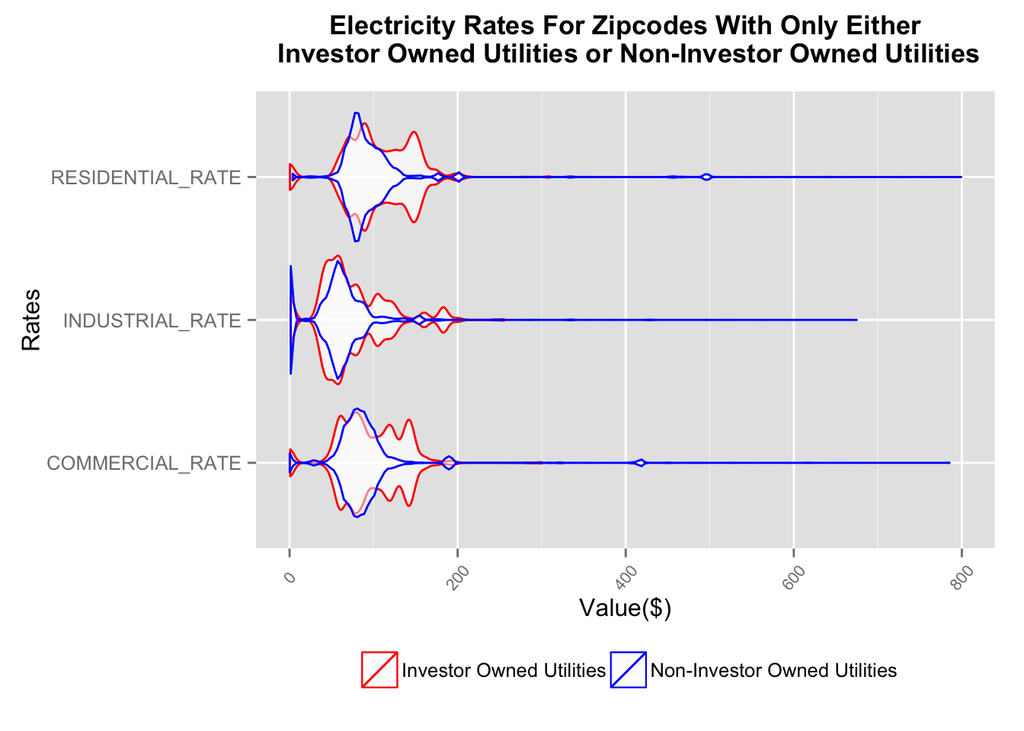

We pivot our focus to areas that have both IOUs and non-IOUs. Again, we use violin plot to visualize so that it will be much easier to compare with the previous plot.

```r
source("../02 Data Wrangling/areas_with_both_io_and_nonio.R", echo = TRUE)
```

```
##
## > ij_df %>% gather("io_rates", "io_value", 4:6) %>%
## +     gather("nonio_rates", "nonio_value", 7:9) %>% ggplot(aes(x = io_rates,
## +     y = io_value) .... [TRUNCATED]
```

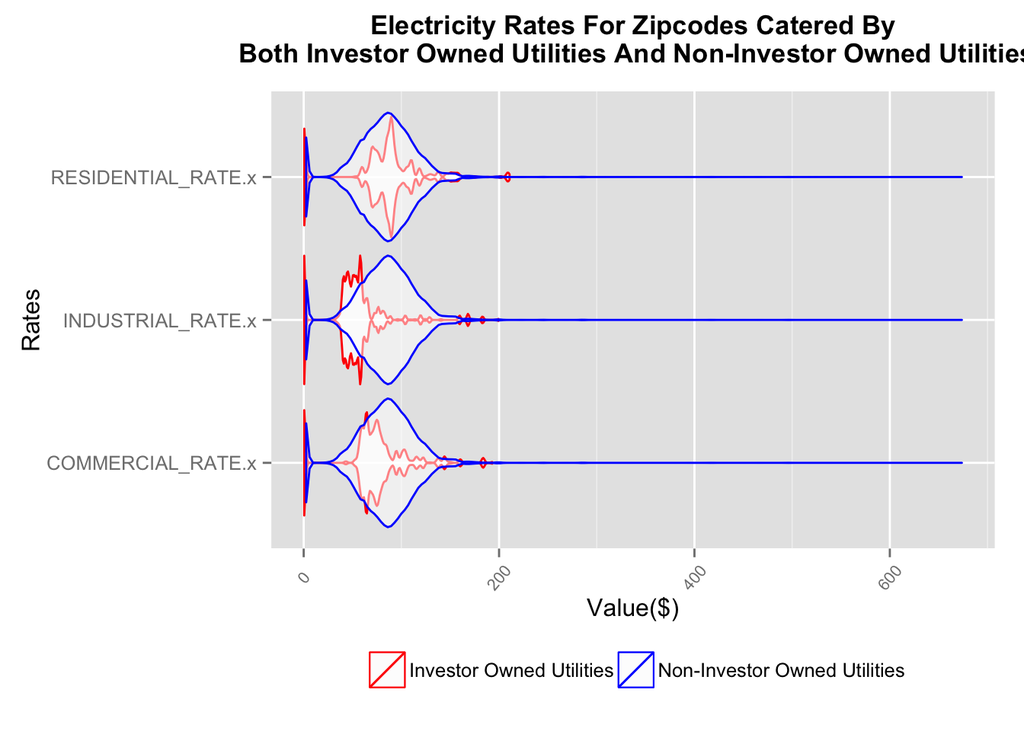

There are a few interesting insights in the plot above: firstly, for non-investor owned utilities, notice that the distributions for all the rates are very similar. Comparing the distribution of rates between IOU and non-IOU, it can be seen that IOU rates are less varied that the non-IOU rates. What’s more surprising to us is that IOUs have much lower industrial rate than the non-IOUs; the interquartile range of IOU’s industrial rate is below the first 50% of the non-IOU’s industrial rate distribution.

From the first two plots, it is evident that electricity rates for the investor owned utilities (IOU) tend to vary less (in terms of distribution) in areas where both types of utilities exist. In fact, in areas where both IOUs and non-IOUs exist, the electricity rates for IOUs tend to be lower then those provided by non-IOUs.

In the previous two violin plots, we can observe that there are many outliers in the distribution. We seek to discover which areas have significantly higher electricity rates. However, since there are many zipcodes, we decided to use state instead so that we are able to intepret the graph more effectively. Thus, we plot the distribution rates againsts their respective states according to the type of rate for investor owned utilities.

```r
source("../02 Data Wrangling/distribution_rates_by_state.R", echo = TRUE)
```

```
##
## > io_df %>% gather("io_rates", "io_value", 4:6) %>%
## +     ggplot(aes(x = io_value, y = state, color = state)) + geom_point() +
## +     facet_wrap(~io_ .... [TRUNCATED]
```

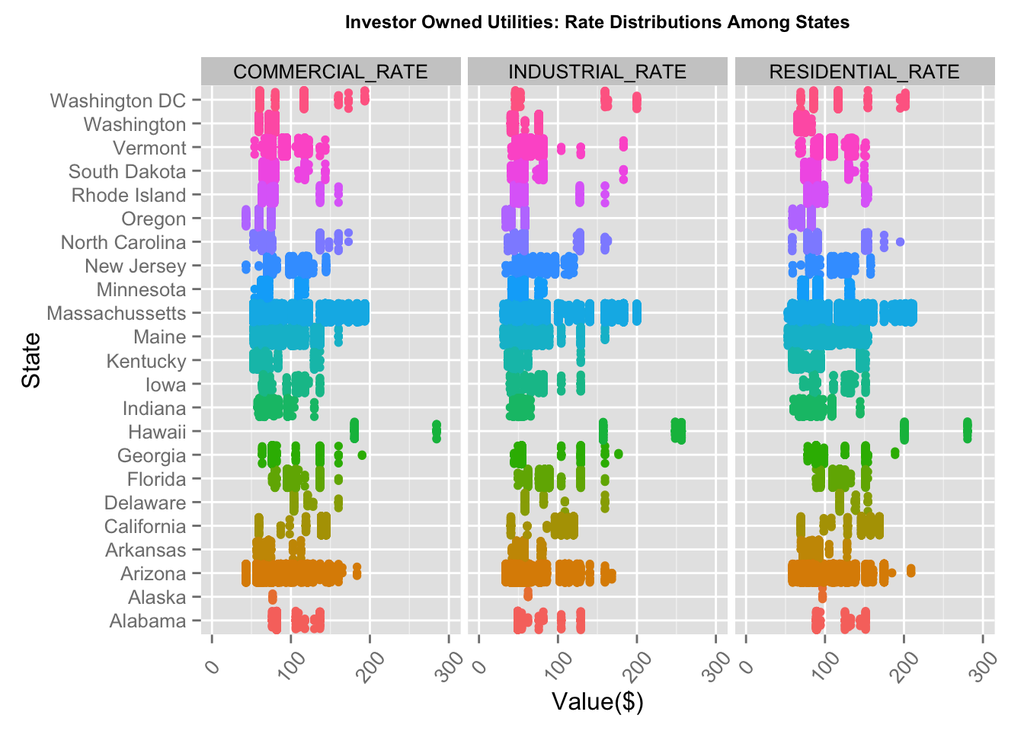

Based on the plot above, it can be seen that Hawaii have significantly higher electricity rates for all types of rate compared to other states. It is also interesting to note here that the distribution between the three types of rate in within a state are quite similar for all states. However, some states like Massachussetts, Arizona and Maine have significantly wider distribution of electricity costs across all rates compared to other states.

The graph below plots the distribution rates of states according to the type of rate for non-investor owned utilities.

```r
source("../02 Data Wrangling/distribution_nonio_rates_by_state.R", echo = TRUE)
```

```
##
## > nonio_df %>% gather("nonio_rates", "nonio_value",
## +     4:6) %>% ggplot(aes(x = nonio_value, y = state, color = state)) +
## +     geom_point() + fac .... [TRUNCATED]
```

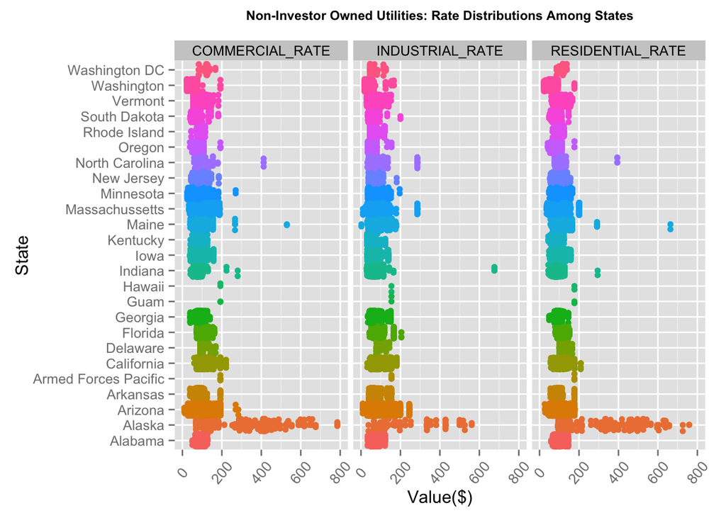

The following bar graphs seek to display IOUs’ average electricty costs for all types of rate for each state.

```r
source("../02 Data Wrangling/mean_rate_state_io.R", echo = TRUE)
```

```
##
## > io_df %>% gather("io_rates", "io_value", 4:6) %>%
## +     select(ZIPCODE, state, io_rates, io_value) %>% group_by(state,
## +     io_rates) %>% summari .... [TRUNCATED]
```

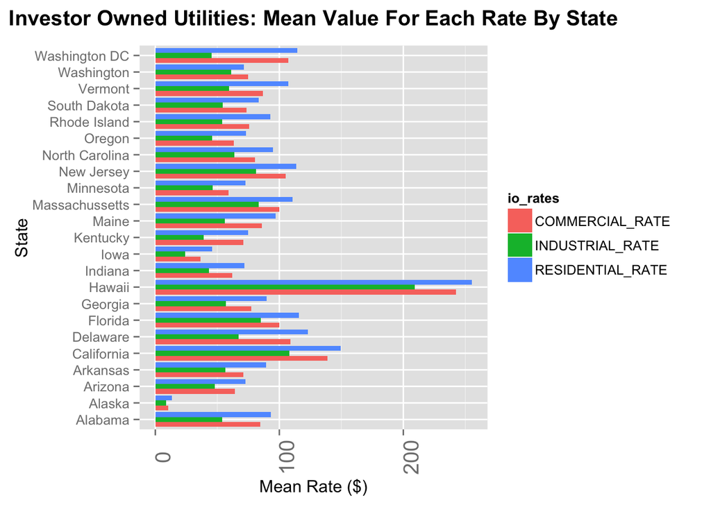

It can be observed from the graph above that Hawaii has the highest mean cost for all types of electricity. Accessibility issue may be the cause of such expensive electricity rate. Setting Hawaii aside, California, Delaware and Florida have the highest electricity cost for residential areas. Meanwhile, California, Delaware and Washington D.C. have the most expensive electrity cost for commercial purpose. For industrial purposes, California, Florida and Massachusetts have the highest electricity rates compared to all the states.

The following graph shows non-IOUs’ average electricty costs for all types of rate for each state.

```r
source("../02 Data Wrangling/mean_rate_state_non_io.R", echo = TRUE)
```

```
##
## > nonio_df %>% gather("nonio_rates", "nonio_value",
## +     4:6) %>% select(ZIPCODE, state, nonio_rates, nonio_value) %>%
## +     group_by(state, nonio_ .... [TRUNCATED]
```

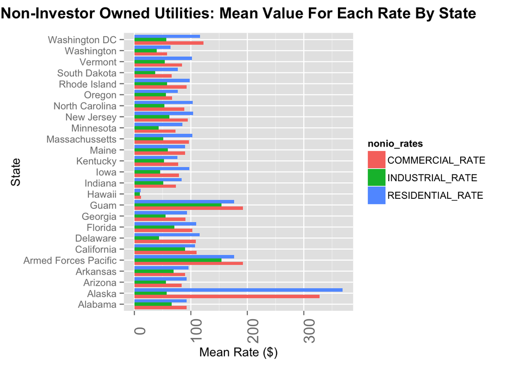

Alaska have significantly higher electricity cost for commercial and residential purposes. We decided to treat Guam and Armed Forces Pacific as special cases because there may be many overhead costs that needed to be covered in order to provide electricity in these places. So setting them aside, we can see that Washington D.C. has the highest cost for commercial and residential purposes while California has the most expensive electricity rate for industrial purposes.